# Does Religiosity Buffer the Negative Effect of Moving on Charitable Giving?

April 22, 2026

Residential moves can disrupt local ties, routines, and institutions that often support charitable giving. This report asks whether pre-move religiosity softens that disruption. Using PSID family data from 2003 to 2021, I test whether moving is associated with lower charitable giving and whether that association is smaller among families that identified as religious in the prior wave.

## Research Question

The core question is straightforward: when families move, does their charitable giving fall, and if so, is the decline smaller for families that were religious before the move?

This framing treats religiosity as a potential stabilizer. If religious attachment ties families to norms, organizations, or replacement networks that survive relocation, then religious families may be better able to sustain giving after a move.

## Data And Measures

The analysis uses 69,218 family-wave observations from 15,663 families in the PSID, covering the biennial waves 2003, 2005, 2007, 2009, 2011, 2013, 2015, 2017, 2019, 2021.

## Results

### Descriptive Patterns

The first figure shows weighted mean giving by move status and pre-move religiosity. It is a simple descriptive comparison, so it should not be read causally, but it provides a useful first look at whether movers and non-movers appear to differ.

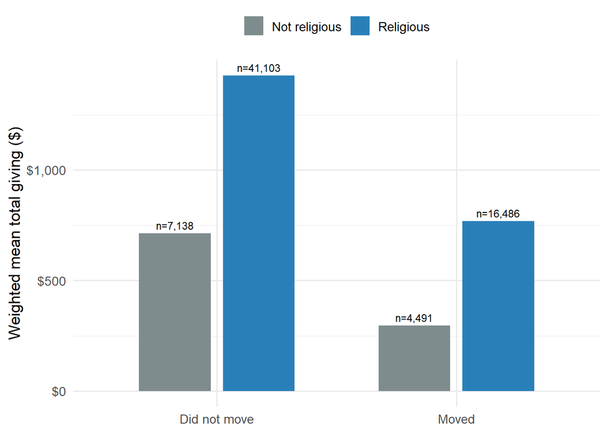

Figure 1. Weighted mean charitable giving by move status and pre-move religiosity.

The year-by-year version is useful because aggregate averages can hide whether the same broad pattern shows up across waves or is being driven by only a small part of the panel.

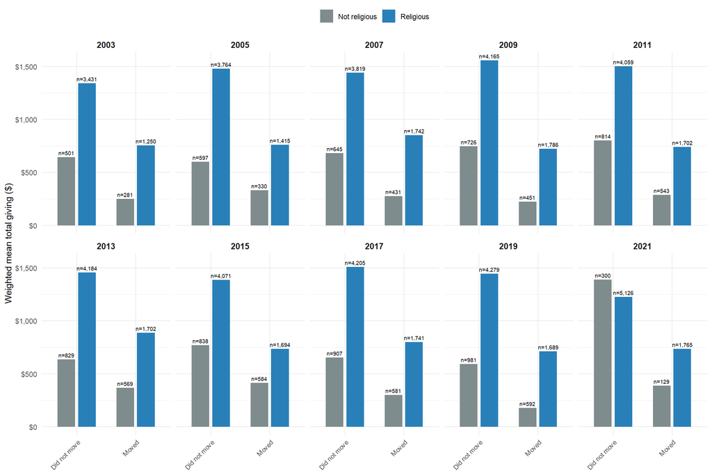

Figure 2. Weighted mean charitable giving by move status and pre-move religiosity, by wave.

### Event-Time Evidence

The next figure is more informative for the report. It follows families with exactly one observed move and indexes each family to the wave immediately before the move (`t = -2`). This keeps the plot focused on change around the disruption rather than permanent level differences between families.

In this one-time-mover sample (841 families), the immediate drop at the move wave is descriptively larger for nonreligious families (-0.991) than for religious families (-0.266) when both are measured relative to their own pre-move baseline. That pattern is consistent with a buffering story, although it remains descriptive.

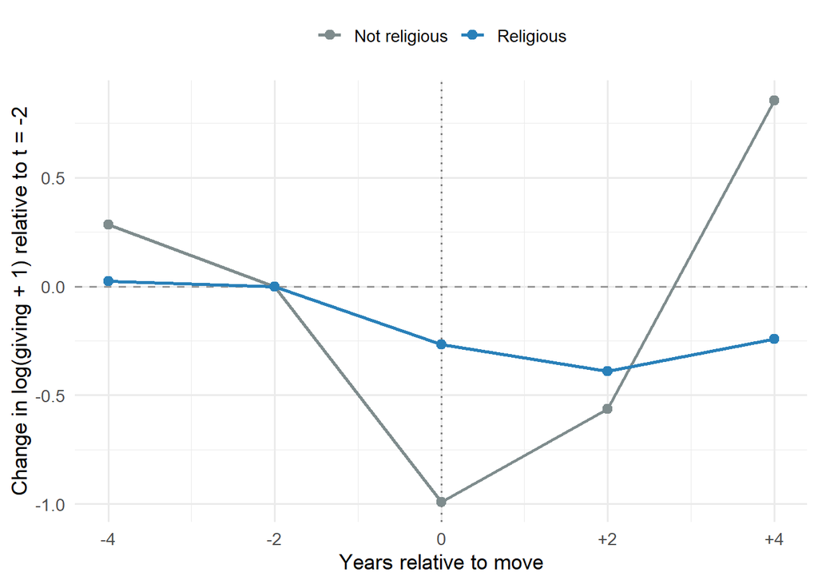

Figure 3. Change in log(giving + 1) around the first observed move, indexed to the prior wave (t = -2). Sample restricted to one-time movers with at least one pre- and post-move observation.

## Interpretation

First, moving is consistently associated with lower charitable giving. Religiosity may soften that decline, but the effect is not proven and would need further research.

That distinction matters. We can reasonably say that the evidence is consistent with a buffering role for religiosity, especially in the immediate period around a move, but it should stop short of claiming a definitive effect.

## Limitations

- Religiosity is measured through reported religious preference, not through attendance, congregation membership, or religious intensity.
- The move indicator is based on the PSID move-reason item and does not capture differences in move distance, disruption, or voluntariness.
- Many families move more than once, so the event-time figure uses a cleaner one-time-mover subsample for interpretability.
- Missing donation responses are folded into the total-giving construction in a way that may understate true giving for some families.